# Application of Convolutional Neural Network on Time Series Data

## Introduction

One interesting topic of time series study is the classification of time series data. Example is like when we have a bench of time series datasets collected from the earthquake censor, and we want to identify what kind of features in these dataset indicate the occurrence of earthquake. Then we need to classify which series is recorded just before earthquake and which is recorded during normal time. In this project, I aim to build a different model to push the limit of time series classification limit based on a subset of UCR time series database.

## Data

```r
name <- "Beef"
path <-"/Users/zhoushanglin/Dropbox/Uconn/6494 Data Science/project_Zhou/"
```

```r
train <- read.table(paste(path, name, "/", name, "_TRAIN", sep = ''), sep = ",")
train
```

| V1 | V2 | V3 | V4 | V5 | V6 | V7 | V8 | V9 | V10 | ⋯ | V462 | V463 | V464 | V465 | V466 | V467 | V468 | V469 | V470 | V471 |
| --- | --- | --- | --- | --- | --- | --- | --- | --- | --- | --- | --- | --- | --- | --- | --- | --- | --- | --- | --- | --- |
| 1 | -0.362920 | -0.365330 | -0.387810 | -0.405590 | -0.399000 | -0.366580 | -0.324540 | -0.31733000 | -0.3265300 | ⋯ | -1.852600 | -1.849300 | -1.849400 | -1.87630 | -1.880500 | -1.858200 | -1.844700 | -1.836200 | -1.840100 | -1.861100 |
| 1 | -0.116280 | -0.116430 | -0.105430 | -0.089785 | -0.065172 | -0.050817 | -0.039526 | -0.02638900 | -0.0225880 | ⋯ | -0.013953 | -0.015909 | -0.023473 | -0.03126 | -0.032699 | -0.037053 | -0.047939 | -0.058936 | -0.052773 | -0.057091 |
| 1 | -0.179320 | -0.181080 | -0.178100 | -0.170050 | -0.157450 | -0.147430 | -0.132370 | -0.12253000 | -0.1164800 | ⋯ | -0.974840 | -0.978760 | -0.981850 | -0.98115 | -0.987070 | -0.992420 | -0.997950 | -1.001200 | -1.001100 | -1.009000 |
| 1 | -0.103760 | -0.095310 | -0.080262 | -0.068881 | -0.051380 | -0.038431 | -0.023409 | -0.01058600 | -0.0076778 | ⋯ | 0.377140 | 0.371430 | 0.371250 | 0.37259 | 0.368070 | 0.364320 | 0.360910 | 0.355500 | 0.356000 | 0.350460 |
| 1 | -0.208100 | -0.196970 | -0.177930 | -0.154310 | -0.121050 | -0.105240 | -0.079494 | -0.04151100 | -0.0252810 | ⋯ | -0.926590 | -0.931170 | -0.934230 | -0.94660 | -0.950460 | -0.952930 | -0.970520 | -0.979610 | -0.968140 | -0.980330 |
| 1 | -0.428020 | -0.444410 | -0.475030 | -0.482680 | -0.484600 | -0.461990 | -0.448950 | -0.46594000 | -0.4695300 | ⋯ | -1.794300 | -1.789300 | -1.792100 | -1.82310 | -1.819900 | -1.811000 | -1.807300 | -1.780500 | -1.782700 | -1.797800 |
| 2 | -0.244440 | -0.251500 | -0.259810 | -0.264670 | -0.267270 | -0.267940 | -0.268330 | -0.26654000 | -0.2631400 | ⋯ | -1.869700 | -1.870500 | -1.870300 | -1.86840 | -1.864900 | -1.864300 | -1.860400 | -1.868300 | -1.871600 | -1.868000 |
| 2 | -0.254170 | -0.258210 | -0.255700 | -0.254420 | -0.256010 | -0.256160 | -0.252610 | -0.24707000 | -0.2455900 | ⋯ | -1.673000 | -1.671000 | -1.676700 | -1.67680 | -1.668600 | -1.665800 | -1.664000 | -1.668900 | -1.671700 | -1.667000 |
| 2 | -0.275780 | -0.279910 | -0.280810 | -0.284030 | -0.282080 | -0.275710 | -0.271210 | -0.26060000 | -0.2526500 | ⋯ | -2.011600 | -2.012400 | -2.007500 | -2.01230 | -2.010200 | -2.000300 | -1.995200 | -2.011400 | -2.009500 | -2.004400 |
| 2 | -0.196110 | -0.190570 | -0.190350 | -0.186940 | -0.183280 | -0.175480 | -0.170330 | -0.16590000 | -0.1516800 | ⋯ | -2.013100 | -2.013900 | -2.015700 | -2.01480 | -2.011100 | -2.010500 | -2.008800 | -2.015000 | -2.018700 | -2.014900 |
| 2 | -0.199590 | -0.191530 | -0.191570 | -0.191590 | -0.185820 | -0.179050 | -0.182410 | -0.18555000 | -0.1729800 | ⋯ | -1.609800 | -1.608900 | -1.609000 | -1.61000 | -1.608700 | -1.609100 | -1.606700 | -1.607300 | -1.610200 | -1.607300 |
| 2 | -0.206770 | -0.216430 | -0.230020 | -0.241650 | -0.249250 | -0.255760 | -0.261140 | -0.26710000 | -0.2720300 | ⋯ | -1.601900 | -1.599600 | -1.600400 | -1.60090 | -1.597400 | -1.598400 | -1.599700 | -1.599900 | -1.597700 | -1.592400 |
| 3 | -0.308700 | -0.307640 | -0.314430 | -0.322140 | -0.328390 | -0.337130 | -0.333760 | -0.31941000 | -0.3110900 | ⋯ | -1.962000 | -1.957300 | -1.956500 | -1.95830 | -1.956500 | -1.961700 | -1.965700 | -1.964900 | -1.959300 | -1.952100 |
| 3 | -0.193900 | -0.203320 | -0.207120 | -0.212510 | -0.215460 | -0.219470 | -0.221150 | -0.22636000 | -0.2268700 | ⋯ | -1.596500 | -1.596200 | -1.591400 | -1.59220 | -1.593900 | -1.595000 | -1.597100 | -1.592800 | -1.591500 | -1.593400 |
| 3 | -0.177650 | -0.175950 | -0.180620 | -0.189070 | -0.206920 | -0.213950 | -0.205530 | -0.19591000 | -0.1867300 | ⋯ | -1.949100 | -1.943100 | -1.944400 | -1.94730 | -1.950100 | -1.951400 | -1.947700 | -1.955800 | -1.951900 | -1.942600 |
| 3 | -0.224420 | -0.227220 | -0.231420 | -0.225740 | -0.221840 | -0.236330 | -0.239930 | -0.22370000 | -0.2058600 | ⋯ | -1.949500 | -1.951300 | -1.960500 | -1.96010 | -1.955500 | -1.948900 | -1.936000 | -1.944000 | -1.951500 | -1.954000 |
| 3 | -0.182720 | -0.177470 | -0.181280 | -0.185330 | -0.182280 | -0.180950 | -0.179730 | -0.17038000 | -0.1579500 | ⋯ | -1.602200 | -1.608500 | -1.610200 | -1.60390 | -1.601500 | -1.602200 | -1.598100 | -1.599000 | -1.597800 | -1.599100 |
| 3 | -0.248270 | -0.255630 | -0.263870 | -0.277880 | -0.287020 | -0.294160 | -0.297000 | -0.30078000 | -0.3029800 | ⋯ | -1.659200 | -1.660200 | -1.657600 | -1.65670 | -1.658700 | -1.662100 | -1.662200 | -1.658200 | -1.658300 | -1.656200 |
| 4 | -0.148000 | -0.147480 | -0.151790 | -0.152280 | -0.163930 | -0.163720 | -0.147720 | -0.13215000 | -0.1145600 | ⋯ | -2.009100 | -2.001100 | -2.002600 | -2.00410 | -2.003200 | -2.001200 | -2.001100 | -2.008700 | -2.006200 | -2.001200 |
| 4 | -0.164800 | -0.165710 | -0.174030 | -0.176660 | -0.181570 | -0.183280 | -0.176270 | -0.16413000 | -0.1459000 | ⋯ | -1.734600 | -1.729900 | -1.726700 | -1.72450 | -1.725600 | -1.723100 | -1.716700 | -1.723800 | -1.723100 | -1.719500 |
| 4 | -0.102030 | -0.096905 | -0.104580 | -0.109510 | -0.104160 | -0.101740 | -0.092552 | -0.05933700 | -0.0283150 | ⋯ | -2.040000 | -2.037200 | -2.033800 | -2.03410 | -2.045700 | -2.047600 | -2.039800 | -2.047900 | -2.043400 | -2.037900 |
| 4 | -0.067976 | -0.053382 | -0.043660 | -0.043185 | -0.038859 | -0.031205 | -0.020462 | -0.00021068 | 0.0216810 | ⋯ | -1.953400 | -1.951000 | -1.949600 | -1.95190 | -1.957300 | -1.956200 | -1.946500 | -1.950600 | -1.952300 | -1.949000 |
| 4 | 0.014463 | 0.034502 | 0.053230 | 0.074883 | 0.095964 | 0.115230 | 0.140510 | 0.16970000 | 0.2059100 | ⋯ | -1.749500 | -1.755400 | -1.754400 | -1.74890 | -1.746200 | -1.743300 | -1.742800 | -1.749500 | -1.749100 | -1.744700 |
| 4 | -0.074313 | -0.070288 | -0.068216 | -0.062148 | -0.054790 | -0.045478 | -0.034455 | -0.02142000 | 0.0008072 | ⋯ | -1.784400 | -1.790500 | -1.787500 | -1.77670 | -1.773500 | -1.775600 | -1.781900 | -1.791600 | -1.785600 | -1.777100 |
| 5 | -0.249620 | -0.257100 | -0.266120 | -0.270870 | -0.274040 | -0.273860 | -0.274420 | -0.27340000 | -0.2659700 | ⋯ | -1.953300 | -1.951000 | -1.950800 | -1.95200 | -1.954100 | -1.954500 | -1.956300 | -1.951800 | -1.951000 | -1.954100 |
| 5 | -0.215730 | -0.225000 | -0.230040 | -0.234230 | -0.239810 | -0.246390 | -0.251600 | -0.25242000 | -0.2475800 | ⋯ | -1.607200 | -1.607600 | -1.606400 | -1.60720 | -1.608800 | -1.608000 | -1.606800 | -1.611000 | -1.608900 | -1.606300 |
| 5 | -0.204180 | -0.216570 | -0.222010 | -0.224090 | -0.227380 | -0.228340 | -0.227060 | -0.22433000 | -0.2220800 | ⋯ | -1.971400 | -1.967600 | -1.966000 | -1.97030 | -1.971900 | -1.970300 | -1.973500 | -1.969900 | -1.966700 | -1.972100 |
| 5 | -0.204650 | -0.202250 | -0.196660 | -0.199790 | -0.194710 | -0.182680 | -0.179910 | -0.17359000 | -0.1631900 | ⋯ | -2.013800 | -2.012900 | -2.015600 | -2.01730 | -2.016200 | -2.014200 | -2.015700 | -2.019000 | -2.014500 | -2.011800 |
| 5 | -0.234730 | -0.239610 | -0.237460 | -0.234890 | -0.227770 | -0.222580 | -0.219850 | -0.21242000 | -0.2054700 | ⋯ | -1.678900 | -1.674500 | -1.683100 | -1.68620 | -1.680300 | -1.673100 | -1.671500 | -1.676100 | -1.675300 | -1.676700 |
| 5 | -0.209390 | -0.214830 | -0.224380 | -0.235810 | -0.246030 | -0.255810 | -0.264870 | -0.27119000 | -0.2731500 | ⋯ | -1.610300 | -1.607900 | -1.609400 | -1.61110 | -1.611700 | -1.610900 | -1.608400 | -1.612000 | -1.611900 | -1.608700 |

## Spectral Analysis

Joseph Fourier showed that any periodic wave can be represented by a sum of simple sine waves. Also, There is a set of sine waves that, when sumed together, are equal to any given wave.

[figure not shown]

$$ f(t) = a_0 + \sum_k{a_k * sin(kwt+\rho_k)} $$

These sine waves each have a frequency and amplitude and phase position.

Sometimes it is difficult to capture the specific feature on time domain of the time series, but when we convert it to spectrum, those kind of feature may become obvious.

### Fourier Transform

Idea: decompose a stationary time series $X_t$ into a combination of sinusoids, with random and uncorrelated coefficients.

$$ F_{X}(k) = \sum_{t=0}^{M-1}X(t)e^{-j \frac{2\pi}{M} t k} $$

for $k = 0, 1, . . . , M − 1$, which represents frequency, M is total length of the series, and $j = \sqrt{-1}$.

## Bispectral Analysis

Because most of the time series data are non-linear, it is better to convert the time series data to bi-spectrum form and salient the specific feature of different class of time series.

$$ B_{X}(k_1, k_2) = \frac{1}{M}F_{X}(k_1)F_{X}(k_2)F_{X}(k_1 + k_2) $$ where $0 \leq k2 \leq k1, k1 + k2 \leq \frac{M}{2}$.

```r
dyn.load(paste(path, "bispectrum/allfortranmac.so", sep = ''))

bispec <- function(x, sm.c = 0.625){
  #
  xx     <- x - mean(x)
  n      <- length(x)
  m      <- trunc(n^sm.c)
  sx     <- rep(0,m)
  z      <- matrix(0, m, m)
  nsq    <- 0
  bs.out <- .Fortran("sq_bispec",
                     as.double(xx),
                     as.integer(n),
                     as.integer(m),
                     as.integer(m),
                     sx = as.double(sx),
                     z = as.double(z),
                     nsq = as.integer(nsq))
  return(list(sx = bs.out$sx, z = matrix(bs.out$z,m,m), nsq = bs.out$nsq, freqs = seq(0,0.5,length=m)))
}
##########################################################################################################
train <- read.table(paste(path, name, "/", name, "_TRAIN", sep = ''), sep = ",")
data_trn <- t(train[,2:dim(train)[2]])
label_trn <- train[,1]

n=length(label_trn)
sm.c=0.625   # constant from Hinich paper
m=n^sm.c

ser = data_trn[, 1]
bispects.data_trn <- z <- matrix(0, m, m)
bispects.data_trn <- bispec(ser,sm.c)$z

dim(bispects.data_trn)
print("------------------")
bispects.data_trn
```

1. 46

2. 46

```
[1] "------------------"
```

[output not shown]

## Plot

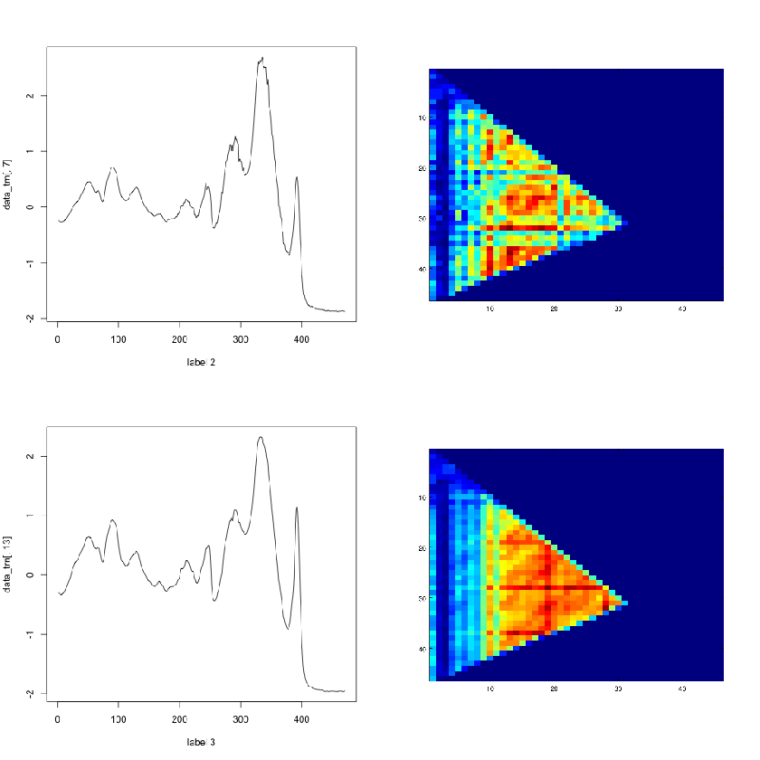

```r
library(png)
library(grid)
library(gridExtra)
# img1  <-  rasterGrob(as.raster(readPNG("Beef_plot/train_ts_ser_1.png")), interpolate = FALSE)
# img2  <-  rasterGrob(as.raster(readPNG("Beef_plot/train_bi_ser_1.png")), interpolate = FALSE)
img3  <-  rasterGrob(as.raster(readPNG("Beef_plot/train_ts_ser_7.png")), interpolate = FALSE)
img4  <-  rasterGrob(as.raster(readPNG("Beef_plot/train_bi_ser_7.png")), interpolate = FALSE)
img5  <-  rasterGrob(as.raster(readPNG("Beef_plot/train_ts_ser_13.png")), interpolate = FALSE)
img6  <-  rasterGrob(as.raster(readPNG("Beef_plot/train_bi_ser_13.png")), interpolate = FALSE)
grid.arrange(img3, img4, img5, img6, ncol = 2, nrow = 2)
```